# Risk Factor Analysis

## Outcome Variable

**Outcome Variable:** ever_sstunted

## Predictor Variables

**Intervention Variable:** parity

**Adjustment Set:**

unadjusted

## Stratifying Variables

The analysis was stratified on these variable(s):

- agecat
- studyid
- country

## Data Summary

| agecat | studyid | country | parity | ever_sstunted | n_cell | n |
| --- | --- | --- | --- | --- | --- | --- |
| 0-24 months | COHORTS | GUATEMALA | 1 | 0 | 121 | 1360 |
| 0-24 months | COHORTS | GUATEMALA | 1 | 1 | 92 | 1360 |
| 0-24 months | COHORTS | GUATEMALA | 2 | 0 | 105 | 1360 |
| 0-24 months | COHORTS | GUATEMALA | 2 | 1 | 87 | 1360 |
| 0-24 months | COHORTS | GUATEMALA | 3+ | 0 | 503 | 1360 |
| 0-24 months | COHORTS | GUATEMALA | 3+ | 1 | 452 | 1360 |
| 0-24 months | COHORTS | INDIA | 1 | 0 | 723 | 4630 |
| 0-24 months | COHORTS | INDIA | 1 | 1 | 89 | 4630 |
| 0-24 months | COHORTS | INDIA | 2 | 0 | 1061 | 4630 |
| 0-24 months | COHORTS | INDIA | 2 | 1 | 124 | 4630 |
| 0-24 months | COHORTS | INDIA | 3+ | 0 | 2205 | 4630 |
| 0-24 months | COHORTS | INDIA | 3+ | 1 | 428 | 4630 |
| 0-24 months | COHORTS | PHILIPPINES | 1 | 0 | 505 | 3058 |
| 0-24 months | COHORTS | PHILIPPINES | 1 | 1 | 173 | 3058 |
| 0-24 months | COHORTS | PHILIPPINES | 2 | 0 | 470 | 3058 |
| 0-24 months | COHORTS | PHILIPPINES | 2 | 1 | 220 | 3058 |
| 0-24 months | COHORTS | PHILIPPINES | 3+ | 0 | 994 | 3058 |
| 0-24 months | COHORTS | PHILIPPINES | 3+ | 1 | 696 | 3058 |
| 0-24 months | GMS-Nepal | NEPAL | 1 | 0 | 159 | 698 |
| 0-24 months | GMS-Nepal | NEPAL | 1 | 1 | 52 | 698 |
| 0-24 months | GMS-Nepal | NEPAL | 2 | 0 | 143 | 698 |
| 0-24 months | GMS-Nepal | NEPAL | 2 | 1 | 38 | 698 |
| 0-24 months | GMS-Nepal | NEPAL | 3+ | 0 | 227 | 698 |
| 0-24 months | GMS-Nepal | NEPAL | 3+ | 1 | 79 | 698 |
| 0-24 months | Keneba | GAMBIA | 1 | 0 | 182 | 1990 |
| 0-24 months | Keneba | GAMBIA | 1 | 1 | 59 | 1990 |
| 0-24 months | Keneba | GAMBIA | 2 | 0 | 173 | 1990 |
| 0-24 months | Keneba | GAMBIA | 2 | 1 | 41 | 1990 |
| 0-24 months | Keneba | GAMBIA | 3+ | 0 | 1158 | 1990 |
| 0-24 months | Keneba | GAMBIA | 3+ | 1 | 377 | 1990 |

[output cut: 90 more lines]

The following strata were considered:

- agecat: 0-24 months, studyid: COHORTS, country: GUATEMALA
- agecat: 0-24 months, studyid: COHORTS, country: INDIA
- agecat: 0-24 months, studyid: COHORTS, country: PHILIPPINES
- agecat: 0-24 months, studyid: GMS-Nepal, country: NEPAL
- agecat: 0-24 months, studyid: Keneba, country: GAMBIA
- agecat: 0-24 months, studyid: PROVIDE, country: BANGLADESH
- agecat: 0-24 months, studyid: SAS-CompFeed, country: INDIA
- agecat: 0-24 months, studyid: SAS-FoodSuppl, country: INDIA
- agecat: 0-24 months, studyid: TanzaniaChild2, country: TANZANIA, UNITED REPUBLIC OF
- agecat: 0-24 months, studyid: ZVITAMBO, country: ZIMBABWE
- agecat: 0-6 months, studyid: COHORTS, country: GUATEMALA
- agecat: 0-6 months, studyid: COHORTS, country: INDIA
- agecat: 0-6 months, studyid: COHORTS, country: PHILIPPINES
- agecat: 0-6 months, studyid: GMS-Nepal, country: NEPAL
- agecat: 0-6 months, studyid: Keneba, country: GAMBIA
- agecat: 0-6 months, studyid: PROVIDE, country: BANGLADESH
- agecat: 0-6 months, studyid: SAS-CompFeed, country: INDIA
- agecat: 0-6 months, studyid: SAS-FoodSuppl, country: INDIA
- agecat: 0-6 months, studyid: TanzaniaChild2, country: TANZANIA, UNITED REPUBLIC OF
- agecat: 0-6 months, studyid: ZVITAMBO, country: ZIMBABWE

### Dropped Strata

Some strata were dropped due to rare outcomes:

- agecat: 0-24 months, studyid: SAS-FoodSuppl, country: INDIA
- agecat: 0-6 months, studyid: SAS-FoodSuppl, country: INDIA

## Methods Detail

We’re interested in the causal parameters $E[Y_a]$ for all values of $a \in \mathcal{A}$. These parameters represent the mean outcome if, possibly contrary to fact, we intervened to set all units to have $A=a$. Under the randomization and positivity assumptions, these are identified by the statistical parameters $\psi_a=E_W[E_{Y|A,W}(Y|A=a,W)]$. In addition, we’re interested in the mean of $Y$, $E[Y]$ under no intervention (the observed mean). We will estimate these parameters by using SuperLearner to fit the relevant likelihood factors – $E_{Y|A,W}(Y|A=a,W)$ and $p(A=a|W)$, and then updating our likelihood fit using a joint TMLE.

For unadjusted analyses ($W=\{\}$), initial likelihoods were estimated using Lrnr_glm to estimate the simple $E(Y|A)$ and Lrnr_mean to estimate $p(A)$. For adjusted analyses, a small library containing Lrnr_glmnet, Lrnr_xgboost, and Lrnr_mean was used.

Having estimated these parameters, we will then use the delta method to estimate relative risks and attributable risks relative to a prespecified baseline level of $A$.

# Results Detail

## Results Plots

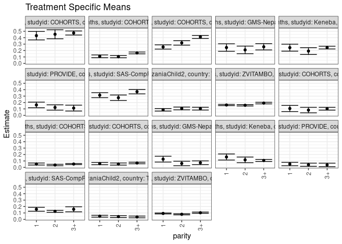

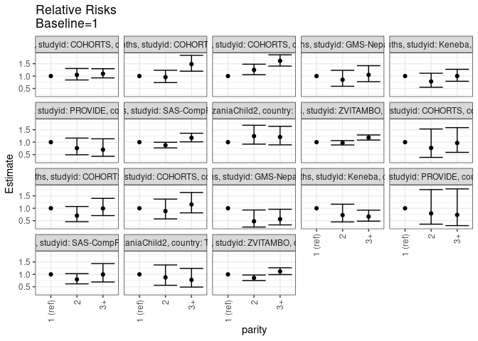

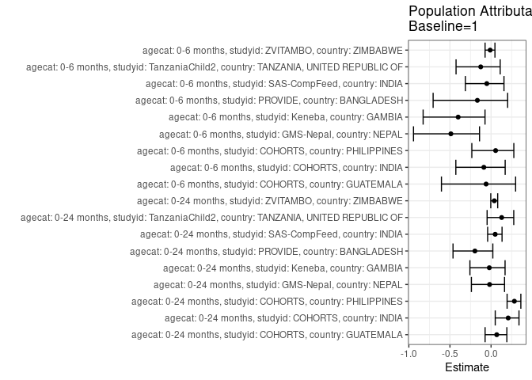

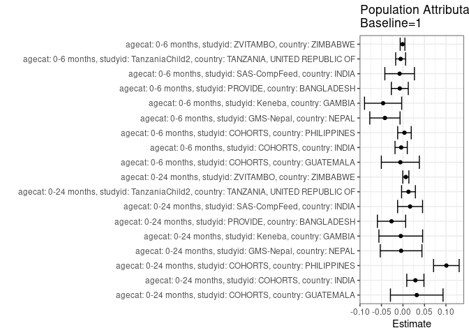

## Results Table

### Parameter: TSM

| agecat | studyid | country | intervention_level | baseline_level | estimate | ci_lower | ci_upper |
| --- | --- | --- | --- | --- | --- | --- | --- |
| 0-24 months | COHORTS | GUATEMALA | 1 | NA | 0.4319249 | 0.3653784 | 0.4984714 |
| 0-24 months | COHORTS | GUATEMALA | 2 | NA | 0.4531250 | 0.3826865 | 0.5235635 |
| 0-24 months | COHORTS | GUATEMALA | 3+ | NA | 0.4732984 | 0.4416206 | 0.5049763 |
| 0-24 months | COHORTS | INDIA | 1 | NA | 0.1096059 | 0.0881165 | 0.1310954 |
| 0-24 months | COHORTS | INDIA | 2 | NA | 0.1046414 | 0.0872118 | 0.1220709 |
| 0-24 months | COHORTS | INDIA | 3+ | NA | 0.1625522 | 0.1484579 | 0.1766466 |
| 0-24 months | COHORTS | PHILIPPINES | 1 | NA | 0.2551622 | 0.2223419 | 0.2879826 |
| 0-24 months | COHORTS | PHILIPPINES | 2 | NA | 0.3188406 | 0.2840625 | 0.3536187 |
| 0-24 months | COHORTS | PHILIPPINES | 3+ | NA | 0.4118343 | 0.3883657 | 0.4353029 |
| 0-24 months | GMS-Nepal | NEPAL | 1 | NA | 0.2464455 | 0.1882572 | 0.3046338 |
| 0-24 months | GMS-Nepal | NEPAL | 2 | NA | 0.2099448 | 0.1505701 | 0.2693194 |
| 0-24 months | GMS-Nepal | NEPAL | 3+ | NA | 0.2581699 | 0.2091013 | 0.3072385 |
| 0-24 months | Keneba | GAMBIA | 1 | NA | 0.2448133 | 0.1905141 | 0.2991125 |
| 0-24 months | Keneba | GAMBIA | 2 | NA | 0.1915888 | 0.1388474 | 0.2443302 |
| 0-24 months | Keneba | GAMBIA | 3+ | NA | 0.2456026 | 0.2240639 | 0.2671413 |
| 0-24 months | PROVIDE | BANGLADESH | 1 | NA | 0.1623616 | 0.1184233 | 0.2063000 |
| 0-24 months | PROVIDE | BANGLADESH | 2 | NA | 0.1229508 | 0.0817182 | 0.1641835 |
| 0-24 months | PROVIDE | BANGLADESH | 3+ | NA | 0.1135135 | 0.0677697 | 0.1592573 |
| 0-24 months | SAS-CompFeed | INDIA | 1 | NA | 0.3141593 | 0.2753794 | 0.3529392 |
| 0-24 months | SAS-CompFeed | INDIA | 2 | NA | 0.2750000 | 0.2320870 | 0.3179130 |
| 0-24 months | SAS-CompFeed | INDIA | 3+ | NA | 0.3689320 | 0.3349333 | 0.4029308 |
| 0-24 months | TanzaniaChild2 | TANZANIA, UNITED REPUBLIC OF | 1 | NA | 0.0864799 | 0.0672496 | 0.1057102 |
| 0-24 months | TanzaniaChild2 | TANZANIA, UNITED REPUBLIC OF | 2 | NA | 0.1076524 | 0.0857702 | 0.1295346 |
| 0-24 months | TanzaniaChild2 | TANZANIA, UNITED REPUBLIC OF | 3+ | NA | 0.1045752 | 0.0828862 | 0.1262641 |
| 0-24 months | ZVITAMBO | ZIMBABWE | 1 | NA | 0.1614764 | 0.1522184 | 0.1707344 |
| 0-24 months | ZVITAMBO | ZIMBABWE | 2 | NA | 0.1569326 | 0.1459474 | 0.1679178 |
| 0-24 months | ZVITAMBO | ZIMBABWE | 3+ | NA | 0.1911920 | 0.1786754 | 0.2037086 |
| 0-6 months | COHORTS | GUATEMALA | 1 | NA | 0.1069182 | 0.0588653 | 0.1549712 |
| 0-6 months | COHORTS | GUATEMALA | 2 | NA | 0.0822785 | 0.0394121 | 0.1251449 |
| 0-6 months | COHORTS | GUATEMALA | 3+ | NA | 0.1033592 | 0.0819026 | 0.1248158 |
| 0-6 months | COHORTS | INDIA | 1 | NA | 0.0522876 | 0.0365113 | 0.0680638 |
| 0-6 months | COHORTS | INDIA | 2 | NA | 0.0367133 | 0.0258146 | 0.0476119 |
| 0-6 months | COHORTS | INDIA | 3+ | NA | 0.0518721 | 0.0432871 | 0.0604570 |
| 0-6 months | COHORTS | PHILIPPINES | 1 | NA | 0.0589971 | 0.0412586 | 0.0767355 |
| 0-6 months | COHORTS | PHILIPPINES | 2 | NA | 0.0521739 | 0.0355786 | 0.0687692 |
| 0-6 months | COHORTS | PHILIPPINES | 3+ | NA | 0.0680473 | 0.0560391 | 0.0800555 |
| 0-6 months | GMS-Nepal | NEPAL | 1 | NA | 0.1279621 | 0.0828569 | 0.1730673 |
| 0-6 months | GMS-Nepal | NEPAL | 2 | NA | 0.0607735 | 0.0259428 | 0.0956042 |
| 0-6 months | GMS-Nepal | NEPAL | 3+ | NA | 0.0718954 | 0.0429321 | 0.1008587 |
| 0-6 months | Keneba | GAMBIA | 1 | NA | 0.1617021 | 0.1146165 | 0.2087878 |
| 0-6 months | Keneba | GAMBIA | 2 | NA | 0.1170732 | 0.0730502 | 0.1610961 |
| 0-6 months | Keneba | GAMBIA | 3+ | NA | 0.1075725 | 0.0914129 | 0.1237322 |
| 0-6 months | PROVIDE | BANGLADESH | 1 | NA | 0.0516605 | 0.0252890 | 0.0780320 |
| 0-6 months | PROVIDE | BANGLADESH | 2 | NA | 0.0409836 | 0.0160904 | 0.0658769 |
| 0-6 months | PROVIDE | BANGLADESH | 3+ | NA | 0.0378378 | 0.0103234 | 0.0653522 |
| 0-6 months | SAS-CompFeed | INDIA | 1 | NA | 0.1574279 | 0.1267104 | 0.1881455 |
| 0-6 months | SAS-CompFeed | INDIA | 2 | NA | 0.1253482 | 0.1101129 | 0.1405835 |
| 0-6 months | SAS-CompFeed | INDIA | 3+ | NA | 0.1569444 | 0.1176418 | 0.1962471 |
| 0-6 months | TanzaniaChild2 | TANZANIA, UNITED REPUBLIC OF | 1 | NA | 0.0487211 | 0.0339918 | 0.0634503 |
| 0-6 months | TanzaniaChild2 | TANZANIA, UNITED REPUBLIC OF | 2 | NA | 0.0428016 | 0.0285112 | 0.0570919 |
| 0-6 months | TanzaniaChild2 | TANZANIA, UNITED REPUBLIC OF | 3+ | NA | 0.0379085 | 0.0243726 | 0.0514444 |
| 0-6 months | ZVITAMBO | ZIMBABWE | 1 | NA | 0.0922138 | 0.0849302 | 0.0994974 |
| 0-6 months | ZVITAMBO | ZIMBABWE | 2 | NA | 0.0789161 | 0.0707689 | 0.0870633 |
| 0-6 months | ZVITAMBO | ZIMBABWE | 3+ | NA | 0.1032480 | 0.0935564 | 0.1129395 |

### Parameter: E(Y)

| agecat | studyid | country | intervention_level | baseline_level | estimate | ci_lower | ci_upper |
| --- | --- | --- | --- | --- | --- | --- | --- |
| 0-24 months | COHORTS | GUATEMALA | NA | NA | 0.4639706 | 0.4374564 | 0.4904847 |
| 0-24 months | COHORTS | INDIA | NA | NA | 0.1384449 | 0.1284958 | 0.1483940 |
| 0-24 months | COHORTS | PHILIPPINES | NA | NA | 0.3561151 | 0.3391405 | 0.3730897 |
| 0-24 months | GMS-Nepal | NEPAL | NA | NA | 0.2421203 | 0.2103189 | 0.2739218 |
| 0-24 months | Keneba | GAMBIA | NA | NA | 0.2396985 | 0.2209375 | 0.2584595 |
| 0-24 months | PROVIDE | BANGLADESH | NA | NA | 0.1357143 | 0.1103250 | 0.1611036 |
| 0-24 months | SAS-CompFeed | INDIA | NA | NA | 0.3307241 | 0.3024794 | 0.3589688 |
| 0-24 months | TanzaniaChild2 | TANZANIA, UNITED REPUBLIC OF | NA | NA | 0.0992787 | 0.0872038 | 0.1113537 |
| 0-24 months | ZVITAMBO | ZIMBABWE | NA | NA | 0.1681234 | 0.1619444 | 0.1743023 |
| 0-6 months | COHORTS | GUATEMALA | NA | NA | 0.1008249 | 0.0829501 | 0.1186997 |
| 0-6 months | COHORTS | INDIA | NA | NA | 0.0480662 | 0.0417969 | 0.0543355 |
| 0-6 months | COHORTS | PHILIPPINES | NA | NA | 0.0624591 | 0.0538810 | 0.0710373 |
| 0-6 months | GMS-Nepal | NEPAL | NA | NA | 0.0859599 | 0.0651504 | 0.1067694 |
| 0-6 months | Keneba | GAMBIA | NA | NA | 0.1154884 | 0.1009322 | 0.1300446 |
| 0-6 months | PROVIDE | BANGLADESH | NA | NA | 0.0442857 | 0.0290345 | 0.0595370 |
| 0-6 months | SAS-CompFeed | INDIA | NA | NA | 0.1496732 | 0.1307571 | 0.1685893 |
| 0-6 months | TanzaniaChild2 | TANZANIA, UNITED REPUBLIC OF | NA | NA | 0.0432754 | 0.0350591 | 0.0514916 |
| 0-6 months | ZVITAMBO | ZIMBABWE | NA | NA | 0.0912066 | 0.0864469 | 0.0959663 |

### Parameter: RR

| agecat | studyid | country | intervention_level | baseline_level | estimate | ci_lower | ci_upper |
| --- | --- | --- | --- | --- | --- | --- | --- |
| 0-24 months | COHORTS | GUATEMALA | 1 | 1 | 1.0000000 | 1.0000000 | 1.0000000 |
| 0-24 months | COHORTS | GUATEMALA | 2 | 1 | 1.0490829 | 0.8428641 | 1.3057561 |
| 0-24 months | COHORTS | GUATEMALA | 3+ | 1 | 1.0957888 | 0.9263484 | 1.2962218 |
| 0-24 months | COHORTS | INDIA | 1 | 1 | 1.0000000 | 1.0000000 | 1.0000000 |
| 0-24 months | COHORTS | INDIA | 2 | 1 | 0.9547054 | 0.7381455 | 1.2348004 |
| 0-24 months | COHORTS | INDIA | 3+ | 1 | 1.4830607 | 1.1968942 | 1.8376471 |
| 0-24 months | COHORTS | PHILIPPINES | 1 | 1 | 1.0000000 | 1.0000000 | 1.0000000 |
| 0-24 months | COHORTS | PHILIPPINES | 2 | 1 | 1.2495602 | 1.0556359 | 1.4791091 |
| 0-24 months | COHORTS | PHILIPPINES | 3+ | 1 | 1.6140096 | 1.4021938 | 1.8578224 |
| 0-24 months | GMS-Nepal | NEPAL | 1 | 1 | 1.0000000 | 1.0000000 | 1.0000000 |
| 0-24 months | GMS-Nepal | NEPAL | 2 | 1 | 0.8518912 | 0.5893634 | 1.2313601 |
| 0-24 months | GMS-Nepal | NEPAL | 3+ | 1 | 1.0475742 | 0.7736567 | 1.4184736 |
| 0-24 months | Keneba | GAMBIA | 1 | 1 | 1.0000000 | 1.0000000 | 1.0000000 |
| 0-24 months | Keneba | GAMBIA | 2 | 1 | 0.7825915 | 0.5495454 | 1.1144656 |
| 0-24 months | Keneba | GAMBIA | 3+ | 1 | 1.0032242 | 0.7903436 | 1.2734446 |
| 0-24 months | PROVIDE | BANGLADESH | 1 | 1 | 1.0000000 | 1.0000000 | 1.0000000 |
| 0-24 months | PROVIDE | BANGLADESH | 2 | 1 | 0.7572653 | 0.4921499 | 1.1651953 |
| 0-24 months | PROVIDE | BANGLADESH | 3+ | 1 | 0.6991400 | 0.4302792 | 1.1359990 |
| 0-24 months | SAS-CompFeed | INDIA | 1 | 1 | 1.0000000 | 1.0000000 | 1.0000000 |
| 0-24 months | SAS-CompFeed | INDIA | 2 | 1 | 0.8753521 | 0.7700930 | 0.9949985 |
| 0-24 months | SAS-CompFeed | INDIA | 3+ | 1 | 1.1743471 | 1.0140791 | 1.3599442 |
| 0-24 months | TanzaniaChild2 | TANZANIA, UNITED REPUBLIC OF | 1 | 1 | 1.0000000 | 1.0000000 | 1.0000000 |
| 0-24 months | TanzaniaChild2 | TANZANIA, UNITED REPUBLIC OF | 2 | 1 | 1.2448256 | 0.9210173 | 1.6824774 |
| 0-24 months | TanzaniaChild2 | TANZANIA, UNITED REPUBLIC OF | 3+ | 1 | 1.2092424 | 0.8921851 | 1.6389728 |
| 0-24 months | ZVITAMBO | ZIMBABWE | 1 | 1 | 1.0000000 | 1.0000000 | 1.0000000 |
| 0-24 months | ZVITAMBO | ZIMBABWE | 2 | 1 | 0.9718610 | 0.8877859 | 1.0638982 |
| 0-24 months | ZVITAMBO | ZIMBABWE | 3+ | 1 | 1.1840246 | 1.0853436 | 1.2916779 |
| 0-6 months | COHORTS | GUATEMALA | 1 | 1 | 1.0000000 | 1.0000000 | 1.0000000 |
| 0-6 months | COHORTS | GUATEMALA | 2 | 1 | 0.7695458 | 0.3867355 | 1.5312810 |
| 0-6 months | COHORTS | GUATEMALA | 3+ | 1 | 0.9667123 | 0.5892423 | 1.5859904 |
| 0-6 months | COHORTS | INDIA | 1 | 1 | 1.0000000 | 1.0000000 | 1.0000000 |
| 0-6 months | COHORTS | INDIA | 2 | 1 | 0.7021416 | 0.4598322 | 1.0721364 |
| 0-6 months | COHORTS | INDIA | 3+ | 1 | 0.9920534 | 0.7032030 | 1.3995531 |
| 0-6 months | COHORTS | PHILIPPINES | 1 | 1 | 1.0000000 | 1.0000000 | 1.0000000 |
| 0-6 months | COHORTS | PHILIPPINES | 2 | 1 | 0.8843478 | 0.5708690 | 1.3699659 |
| 0-6 months | COHORTS | PHILIPPINES | 3+ | 1 | 1.1534024 | 0.8139051 | 1.6345113 |
| 0-6 months | GMS-Nepal | NEPAL | 1 | 1 | 1.0000000 | 1.0000000 | 1.0000000 |
| 0-6 months | GMS-Nepal | NEPAL | 2 | 1 | 0.4749335 | 0.2423374 | 0.9307760 |
| 0-6 months | GMS-Nepal | NEPAL | 3+ | 1 | 0.5618494 | 0.3289615 | 0.9596101 |
| 0-6 months | Keneba | GAMBIA | 1 | 1 | 1.0000000 | 1.0000000 | 1.0000000 |
| 0-6 months | Keneba | GAMBIA | 2 | 1 | 0.7240051 | 0.4499812 | 1.1649008 |
| 0-6 months | Keneba | GAMBIA | 3+ | 1 | 0.6652512 | 0.4793888 | 0.9231739 |
| 0-6 months | PROVIDE | BANGLADESH | 1 | 1 | 1.0000000 | 1.0000000 | 1.0000000 |
| 0-6 months | PROVIDE | BANGLADESH | 2 | 1 | 0.7933255 | 0.3588172 | 1.7540002 |
| 0-6 months | PROVIDE | BANGLADESH | 3+ | 1 | 0.7324324 | 0.3012417 | 1.7808198 |
| 0-6 months | SAS-CompFeed | INDIA | 1 | 1 | 1.0000000 | 1.0000000 | 1.0000000 |
| 0-6 months | SAS-CompFeed | INDIA | 2 | 1 | 0.7962258 | 0.6163824 | 1.0285426 |
| 0-6 months | SAS-CompFeed | INDIA | 3+ | 1 | 0.9969288 | 0.6922798 | 1.4356436 |
| 0-6 months | TanzaniaChild2 | TANZANIA, UNITED REPUBLIC OF | 1 | 1 | 1.0000000 | 1.0000000 | 1.0000000 |
| 0-6 months | TanzaniaChild2 | TANZANIA, UNITED REPUBLIC OF | 2 | 1 | 0.8785019 | 0.5599281 | 1.3783300 |
| 0-6 months | TanzaniaChild2 | TANZANIA, UNITED REPUBLIC OF | 3+ | 1 | 0.7780719 | 0.4873385 | 1.2422492 |
| 0-6 months | ZVITAMBO | ZIMBABWE | 1 | 1 | 1.0000000 | 1.0000000 | 1.0000000 |
| 0-6 months | ZVITAMBO | ZIMBABWE | 2 | 1 | 0.8557949 | 0.7514781 | 0.9745926 |
| 0-6 months | ZVITAMBO | ZIMBABWE | 3+ | 1 | 1.1196585 | 0.9903929 | 1.2657958 |

### Parameter: PAR

| agecat | studyid | country | intervention_level | baseline_level | estimate | ci_lower | ci_upper |
| --- | --- | --- | --- | --- | --- | --- | --- |
| 0-24 months | COHORTS | GUATEMALA | 1 | NA | 0.0320457 | -0.0291449 | 0.0932363 |
| 0-24 months | COHORTS | INDIA | 1 | NA | 0.0288390 | 0.0088690 | 0.0488091 |
| 0-24 months | COHORTS | PHILIPPINES | 1 | NA | 0.1009529 | 0.0711592 | 0.1307466 |
| 0-24 months | GMS-Nepal | NEPAL | 1 | NA | -0.0043252 | -0.0528037 | 0.0441533 |
| 0-24 months | Keneba | GAMBIA | 1 | NA | -0.0051148 | -0.0559699 | 0.0457403 |
| 0-24 months | PROVIDE | BANGLADESH | 1 | NA | -0.0266473 | -0.0595164 | 0.0062217 |
| 0-24 months | SAS-CompFeed | INDIA | 1 | NA | 0.0165648 | -0.0124377 | 0.0455673 |
| 0-24 months | TanzaniaChild2 | TANZANIA, UNITED REPUBLIC OF | 1 | NA | 0.0127988 | -0.0032630 | 0.0288607 |
| 0-24 months | ZVITAMBO | ZIMBABWE | 1 | NA | 0.0066470 | -0.0004215 | 0.0137155 |
| 0-6 months | COHORTS | GUATEMALA | 1 | NA | -0.0060933 | -0.0503149 | 0.0381283 |
| 0-6 months | COHORTS | INDIA | 1 | NA | -0.0042214 | -0.0184713 | 0.0100285 |
| 0-6 months | COHORTS | PHILIPPINES | 1 | NA | 0.0034621 | -0.0123085 | 0.0192327 |
| 0-6 months | GMS-Nepal | NEPAL | 1 | NA | -0.0420022 | -0.0771803 | -0.0068241 |
| 0-6 months | Keneba | GAMBIA | 1 | NA | -0.0462137 | -0.0894179 | -0.0030096 |
| 0-6 months | PROVIDE | BANGLADESH | 1 | NA | -0.0073748 | -0.0271125 | 0.0123629 |
| 0-6 months | SAS-CompFeed | INDIA | 1 | NA | -0.0077547 | -0.0421491 | 0.0266396 |
| 0-6 months | TanzaniaChild2 | TANZANIA, UNITED REPUBLIC OF | 1 | NA | -0.0054457 | -0.0169921 | 0.0061007 |
| 0-6 months | ZVITAMBO | ZIMBABWE | 1 | NA | -0.0010072 | -0.0064795 | 0.0044651 |

### Parameter: PAF

| agecat | studyid | country | intervention_level | baseline_level | estimate | ci_lower | ci_upper |
| --- | --- | --- | --- | --- | --- | --- | --- |
| 0-24 months | COHORTS | GUATEMALA | 1 | NA | 0.0690684 | -0.0726572 | 0.1920684 |
| 0-24 months | COHORTS | INDIA | 1 | NA | 0.2083068 | 0.0507808 | 0.3396908 |
| 0-24 months | COHORTS | PHILIPPINES | 1 | NA | 0.2834838 | 0.1949952 | 0.3622455 |
| 0-24 months | GMS-Nepal | NEPAL | 1 | NA | -0.0178637 | -0.2391332 | 0.1638942 |
| 0-24 months | Keneba | GAMBIA | 1 | NA | -0.0213384 | -0.2571432 | 0.1702360 |
| 0-24 months | PROVIDE | BANGLADESH | 1 | NA | -0.1963488 | -0.4626635 | 0.0214766 |
| 0-24 months | SAS-CompFeed | INDIA | 1 | NA | 0.0500864 | -0.0415103 | 0.1336275 |
| 0-24 months | TanzaniaChild2 | TANZANIA, UNITED REPUBLIC OF | 1 | NA | 0.1289182 | -0.0481262 | 0.2760572 |
| 0-24 months | ZVITAMBO | ZIMBABWE | 1 | NA | 0.0395365 | -0.0034250 | 0.0806586 |
| 0-6 months | COHORTS | GUATEMALA | 1 | NA | -0.0604345 | -0.6034972 | 0.2987070 |
| 0-6 months | COHORTS | INDIA | 1 | NA | -0.0878249 | -0.4283632 | 0.1715251 |
| 0-6 months | COHORTS | PHILIPPINES | 1 | NA | 0.0554294 | -0.2339004 | 0.2769160 |
| 0-6 months | GMS-Nepal | NEPAL | 1 | NA | -0.4886256 | -0.9432601 | -0.1403549 |
| 0-6 months | Keneba | GAMBIA | 1 | NA | -0.4001591 | -0.8261769 | -0.0735244 |
| 0-6 months | PROVIDE | BANGLADESH | 1 | NA | -0.1665278 | -0.7044880 | 0.2016446 |
| 0-6 months | SAS-CompFeed | INDIA | 1 | NA | -0.0518111 | -0.3124778 | 0.1570855 |
| 0-6 months | TanzaniaChild2 | TANZANIA, UNITED REPUBLIC OF | 1 | NA | -0.1258389 | -0.4257008 | 0.1109543 |
| 0-6 months | ZVITAMBO | ZIMBABWE | 1 | NA | -0.0110429 | -0.0728560 | 0.0472087 |